# Task 3 - Emily Pelstring

Emily Pelstring

10/27/2021

**Data:** Reed, D. 2020. SBC LTER: Reef: Long-term experiment: Kelp removal: Urchin size frequency distribution ver 20. Environmental Data Initiative. https://doi.org/10.6073/pasta/5a1e9ef03aa47bd2225c0bb98a02a63b.

This code helps to examine data that was collected by divers on red and purple sea urchins at sites of long-term kelp removal experimentation sites. In this code, we visualize the difference in sizes between red and purple sea urchins using histograms and statistical values, such as mean and standard deviation. We then examine purple sea urchins and their population size by site, then by year, via histogram.

## Set Up

Read in the packages that are needed.

```r
knitr::opts_chunk$set(echo = TRUE, message = FALSE, warning = FALSE)
library(here)
library(tidyverse)
library(lubridate)
library(janitor)
library(kableExtra)
library(ggthemes)
```

## Read in the Data

Reading in the urchin data.

```r
urchins <- read_csv(here("data","urchins.csv"))
```

## Cleaning Up Data

Applying clean_names to the urchin data set.

```r
urchins_clean <- urchins %>%
  clean_names() #clean names is in the janitor package
```

## Data Visualization

Here we utilize a histogram plot to visualize the different sizes of urchins, separated into species.

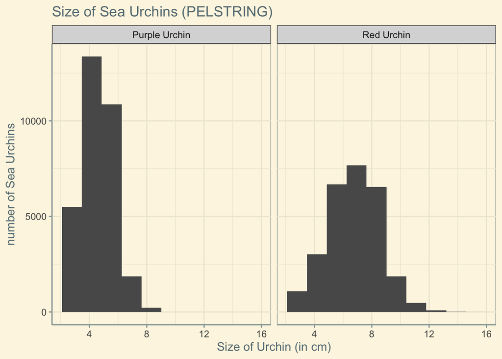

```r
ggplot(data = urchins_clean, #selecting the data
       aes(x = size)) + #making the x axis based on size
  geom_histogram(bins = 10) + #changing bins from 30 to 10
  facet_wrap(~ common_name) + #separating out species
  theme_solarized() +
  labs(x = "Size of Urchin (in cm)",
       y = "number of Sea Urchins",
       title = "Size of Sea Urchins (PELSTRING)")
```

Figure #1: **Size of Sea Urchins by Species.** Sea urchin size was recorded for two different species, the Red Sea Urchin and the Purple Sea Urchin. The number of sea urchins at each corresponding size is represented by the height of the histogram bars, with measured size of the sea urchin on x-axis in centimeters (cm).

## Descriptive Statistics Table

```r
urchin_statistics <- urchins_clean %>% #selecting the data
  group_by(common_name) %>% #grouping by species/common name
  summarize(mean_size_cm = round(mean(size, na.rm = TRUE), 1), #finding the mean, rounding to 1 decimal place
            median_size_cm = round(median(size, na.rm = TRUE), 1), #finding the median, rounding to 1 decimal place
            sd_size_cm = round(sd(size, na.rm = TRUE), 1), #finding the sd, rounding to 1 decimal place
            sample_size = n()) #adding sample size

urchin_statistics %>% #creating a table for the HTML doc
  kable(col.names = c("Common Name", #adding column names
                      "Mean Size (cm)",
                      "Median Size (cm)",
                      "Standard Deviation (cm)",
                      "Sample Size"),
        caption = "Figure #2: Mean, Median, SD, and Sample Size of Sea Urchin Size by Species: Sea urchin size was recorded (in cm) for two species, Red Sea Urchins (n = 27408) and Purple Sea Urchins (n = 31805). The mean Red Sea Urchin size is 6.8 cm +/- 1.9 cm, while the mean Purple Sea Urchin size is 4.5 cm +/- 1.2 cm. The median Red Sea Urchin size is 7.0 cm, and the median Purple Sea Urchin size is 4.5 cm.") %>%
  kable_styling(full_width = FALSE) #styling preference
```

Figure #2: Mean, Median, SD, and Sample Size of Sea Urchin Size by Species: Sea urchin size was recorded (in cm) for two species, Red Sea Urchins (n = 27408) and Purple Sea Urchins (n = 31805). The mean Red Sea Urchin size is 6.8 cm +/- 1.9 cm, while the mean Purple Sea Urchin size is 4.5 cm +/- 1.2 cm. The median Red Sea Urchin size is 7.0 cm, and the median Purple Sea Urchin size is 4.5 cm.

| Common Name | Mean Size (cm) | Median Size (cm) | Standard Deviation (cm) | Sample Size |
| --- | --- | --- | --- | --- |
| Purple Urchin | 4.5 | 4.5 | 1.2 | 31805 |
| Red Urchin | 6.8 | 7.0 | 1.9 | 27408 |

## Exploring Purple Urchin Count by Site and Year

In this code we choose to look at only purple sea urchins, and divide the observations by both site and year. We also mutate the date so that it goes from a ‘character’ to a ‘date’ category in R.

```r
purple_urchins <- urchins_clean %>%
  filter(common_name == "Purple Urchin") %>% #filtering for Purple Urchin
  mutate(date_new = mdy(date)) %>% #converting date into a date category
  mutate(year_new = year(date_new)) %>% #create a column with only year
  mutate(site_full = case_when( #changing the site name acronyms into their full names
    site %in% c("NAPL") ~ "Naples Reef",
    site %in% c("AQUE") ~ "Arroyo Quemado Reef",
    site %in% c("CARP") ~ "Carpinteria Reef",
    site %in% c("MOHK") ~ "Mohawk Reef",
    site %in% c("IVEE") ~ "Isla Vista Reef"))

total_urchin_observations <- purple_urchins %>% #grouping the data by site and year, asking R to count total sea urchins by those groups
  group_by(site_full, year_new) %>%
  count(common_name)
```

## Visualization of Purple Urchins at Each Site By Year

Visualization of purple sea urchins at each site by year using a histogram plot and facet_wrap by full name of site.

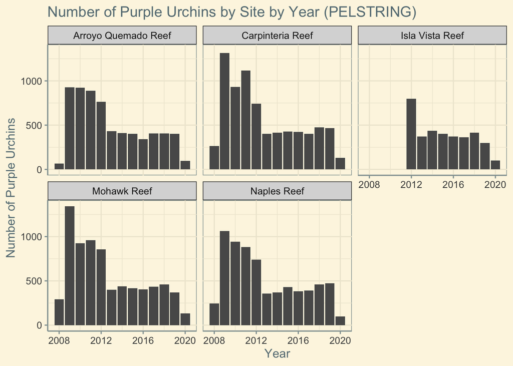

```r
ggplot(data = total_urchin_observations, #selecting the data
       aes(x = year_new,#setting x-axis by year
           y = n)) + #setting y-axis as number of purple urchins
  geom_col() + #defining type of graph
  facet_wrap(~ site_full) + #separating out by site
  theme_solarized() + #adding a theme
  labs(x = "Year", #axes!!
       y = "Number of Purple Urchins",
       title = "Number of Purple Urchins by Site by Year (PELSTRING)") #title!!
```

Figure #3: **Number of Purple Sea Urchins by Site and Year:** Purple sea urchin size was recorded (in cm) at five different sites from 2008-2020. The x-axis separates the data by year, while the y-axis represents the number of sea urchins recorded at that site for the given year.

One factor that you would need to take into account to confirm that the changes in purple urchin population is accurate is the potential of the urchins to move out of the specified sampling areas (such as Mohawk Reef, Naples Reef) into other areas that are not being evaluated. This would make it appear as though urchin population is declining, when in reality there has just been a shift in purple urchin habitat preferences. This shift in habitat preferences could have been caused by increases in water temperatures, as they search to shift towards waters that fit their ideal climate.